# week7

Paul Anderson

10/5/2017

## Reading in the data

```r
library(readxl)

Fake_Data_and_Metadata_Final_no_pass <- read_excel("~/data101fall2017/Fake+Data+and+Metadata+-+Final+no+pass.xlsx",
                                                   sheet = "Daily use of a WF credit card ")
```

## How to summarize and pivot data

```r
library(reshape)
reshaped_df = cast(Fake_Data_and_Metadata_Final_no_pass, masked_id ~ Des1, value = 'Payment', fun.aggregate=sum)
# when we do this it is a good idea to fix the names of the columns
tidy.name.vector <- make.names(colnames(reshaped_df), unique=TRUE)
colnames(reshaped_df) = tidy.name.vector
```

Here I just make sure that we don’t have any missing values, or more specifically that missing values are set to 0 because there was nothing spent in this category.

```r
reshaped_df[is.na(reshaped_df)] = 0
```

Take a gander at the data

```r
head(reshaped_df)
```

```
##   masked_id AIRLINES ALCOHOL ANTIQUES APPLIANCES AUTO BARS
## 1         1     2709       0      751        964  184    0
## 2         2        0    1286      755        914   60 1192
## 3         3     5463     381      262        672  122  610
## 4         6     2951     115      157        330  197  673
## 5         7     4717     469      923          0   44  774
## 6         9     2639     696      102        533   57  185
##   BUILDING.SUPPLY.WHOLESALE CHARITY.COMMUNITY.ORG CLOTHES COMPUTERS
## 1                      6402                   151     105         0
## 2                      1112                   347     154      1109
## 3                      4403                   681     365       175
## 4                      2666                    60     638       277
## 5                      1157                   172     192         0
## 6                      6129                   304     370       464
##   CONTRACTOR.BUSINESS.SERVICES CONVENIENCE.STORES DEPARTMENT.STORES
```

[output cut: 62 more lines]

One thing that bugs me and causes some headaches a little later is that masked_id is a column when it should more accurately be called the row name. Easy to fix.

```r
rownames(reshaped_df) = reshaped_df$masked_id
reshaped_df = reshaped_df[,-1] # Remove the first column
head(reshaped_df)
```

```
##   AIRLINES ALCOHOL ANTIQUES APPLIANCES AUTO BARS BUILDING.SUPPLY.WHOLESALE
## 1     2709       0      751        964  184    0                      6402
## 2        0    1286      755        914   60 1192                      1112
## 3     5463     381      262        672  122  610                      4403
## 6     2951     115      157        330  197  673                      2666
## 7     4717     469      923          0   44  774                      1157
## 9     2639     696      102        533   57  185                      6129
##   CHARITY.COMMUNITY.ORG CLOTHES COMPUTERS CONTRACTOR.BUSINESS.SERVICES
## 1                   151     105         0                         1227
## 2                   347     154      1109                          772
## 3                   681     365       175                          985
## 6                    60     638       277                         1214
## 7                   172     192         0                          489
## 9                   304     370       464                          516
##   CONVENIENCE.STORES DEPARTMENT.STORES DIRECT.MARKETING DISCOUNT.STORES
```

[output cut: 62 more lines]

## Normalizing the data

Easier to think in terms of percentage of expenses

```r
reshaped_df_norm = t(apply(reshaped_df, 1, function(x) x/sum(x))) # divide every row by the sum of that row
# this returns a matrix without column names, so we need to add them back and change back to a data frame
colnames(reshaped_df_norm) = colnames(reshaped_df)
reshaped_df_norm = as.data.frame(reshaped_df_norm)
```

## Now we can do some predictions

```r
library(randomForest)
fit <- randomForest(ALCOHOL ~ .,
                    data=reshaped_df_norm,
                    importance=TRUE,
                    ntree=2000)
print(fit)
```

```
##
## Call:
##  randomForest(formula = ALCOHOL ~ ., data = reshaped_df_norm,      importance = TRUE, ntree = 2000)
##                Type of random forest: regression
##                      Number of trees: 2000
## No. of variables tried at each split: 18
##
##           Mean of squared residuals: 6.699771e-05
##                     % Var explained: -2.8
```

You need to pay attention to the percent variance explained. We want this number to be positive and high. Negative is very very bad. Showing that we should have just guessed.

## All the predictions!

```r
fits = list() # Store the results in a list for examination later
for (i in 1:ncol(reshaped_df_norm)) {
  fits[[i]] <- randomForest(reshaped_df_norm[,i] ~ .,
                      data=reshaped_df_norm,
                      importance=TRUE,
                      ntree=2000)
}
```

If you want to grab all of the percent variance explained for each prediction:

```r
perVarExp = c()
for (i in 1:ncol(reshaped_df_norm)) {
  perVarExp[i] = fits[[i]]$rsq[length(fits[[i]]$rsq)]
}
```

Now we can visualize this:

```r
inxs = order(perVarExp)
mydata = data.frame(perVarExp = perVarExp[inxs], var_names=factor(colnames(reshaped_df_norm)[inxs],ordered = T))
levels(mydata$var_names) = colnames(reshaped_df_norm)[inxs]
library(plotly)
p <- plot_ly(
  x = perVarExp[inxs],
  y = factor(colnames(reshaped_df_norm)[inxs],levels = colnames(reshaped_df_norm)[inxs]),
  name = "Percent Variance Explained",
  type = "bar"
)

p
```

[interactive chart not shown]

## What if you wanted to zero in on a specific user?

```r
masked_id = 1
row_id = which(rownames(reshaped_df_norm)==masked_id)
train.data = reshaped_df_norm[-row_id,]
# Remove that user from the models
masked_id_fits = list() # Store the results in a list for examination later
for (i in 1:ncol(reshaped_df_norm)) {
  masked_id_fits[[i]] <- randomForest(train.data[,i] ~ .,
                      data=train.data,
                      importance=TRUE,
                      ntree=2000)
}
```

# Now let’s calculate for that user where we made the worst predictions

```r
predictions = c()
for (i in 1:ncol(reshaped_df_norm)) {
  predictions[i] = predict(masked_id_fits[[i]],reshaped_df_norm[row_id,])
}
errors = abs(predictions - as.vector(as.matrix(reshaped_df_norm[row_id,])))
```

Now we can visualize this:

```r
inxs = order(errors)
library(plotly)

p <- plot_ly(
  x = 100*as.vector(errors[inxs]),
  y = factor(colnames(reshaped_df_norm)[inxs],levels = colnames(reshaped_df_norm)[inxs]),
  name = "Errors",
  type = "bar"
)

p
```

[interactive chart not shown]

## Looking into the links

```r
library(readxl)
traffic <- read_excel("~/data101fall2017/Fake+Data+and+Metadata+-+Final+no+pass.xlsx",
    sheet = "Daily WellsFargo.com traffic")

# Fix the date
traffic$date = as.Date(traffic$Date,"%m%d%Y")
```

The problem with the links is there is a different number of sublinks to deal with. Let’s clean it up by removing trailing / and by finding out how many slashes there are.

```r
max_slashes = 0
for (i in 1:nrow(traffic)) {
  traffic[i,]$wf_page = gsub('/$', '', traffic[i,]$wf_page)
  fields = strsplit(traffic[i,]$wf_page,"/")[[1]]
  if (max_slashes < length(fields)) {
    max_slashes = length(fields)
  }
}
```

I found that the maximum slashes was 3, so I can make url1, url2, and url3

```r
traffic$url1 = ""
traffic$url2 = ""
traffic$url3 = ""
```

Then I can actually fill it up!

```r
for (i in 1:nrow(traffic)) {
  fields = strsplit(traffic[i,]$wf_page,"/")[[1]]
  traffic$url1[i] = fields[1]
  # If conditions are to make sure we have enough slashes
  if (length(fields) >= 2) {
    traffic$url2[i] = fields[2]
  }
  if (length(fields) >= 3) {
    traffic$url3[i] = fields[3]
  }
}
```

Take a look:

```r
head(traffic)
```

```
## Source: local data frame [6 x 7]
##
##   masked_id     Date
##       (dbl)    (chr)
## 1         1 07012016
## 2         1 07012016
## 3         1 07012016
## 4         1 07012016
## 5         1 07012016
## 6         1 07012016
## Variables not shown: wf_page (chr), date (date), url1 (chr), url2 (chr),
##   url3 (chr)
```

Now we can use cast to pivot again:

```r
library(reshape)
traffic$value = 1
traffic_cast = cast(traffic, masked_id ~ url1, length)
rownames(traffic_cast) = traffic_cast$masked_id
traffic_cast = traffic_cast[,-1]
traffic_cast[is.na(traffic_cast)] = 0
tidy.name.vector <- make.names(colnames(traffic_cast), unique=TRUE)
colnames(traffic_cast) = tidy.name.vector
```

Now let’s see if there are any correlations!

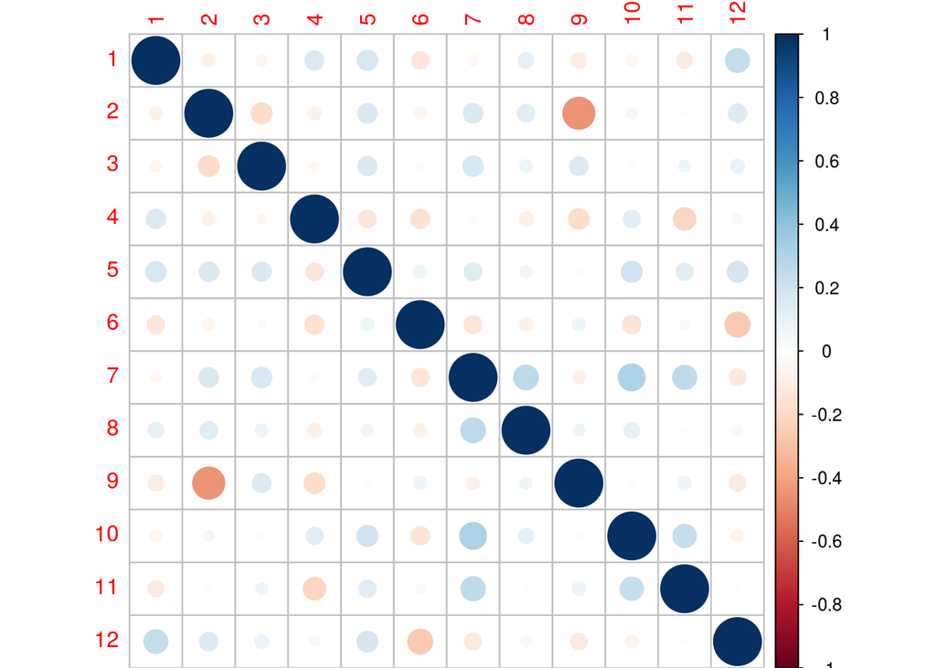

```r
library(corrplot)
M = cor(traffic_cast)
corrplot(M)
```

Looks like 9 and 2 are coorelated for example. What are those?

```r
colnames(traffic_cast)[c(9,2)]
```

```
## [1] "Rewards.and.Benefits"  "Accounts.and.Services"
```

How do we formalize this even more?

### Market Basket Analysis

http://www.salemmarafi.com/code/market-basket-analysis-with-r/

When the dataset is in single form it means that each record represents one single item and each item contains a transaction id. We need to figure out what our transaction id is and then pivot based on that. I don’t think it is just masked_id. I am going to say it is masked_id plus the date.

```r
library(reshape)
traffic$value = 1
traffic_cast2 = cast(traffic, masked_id + date ~ url1, length)
transactionID = paste(traffic_cast2$masked_id,traffic_cast2$date)
# Remove unnecessary columns
traffic_cast2 = traffic_cast2[,-which(colnames(traffic_cast2) == "date")]
traffic_cast2 = traffic_cast2[,-which(colnames(traffic_cast2) == "masked_id")]
traffic_cast2[is.na(traffic_cast2)] = 0
tidy.name.vector <- make.names(colnames(traffic_cast2), unique=TRUE)
colnames(traffic_cast2) = tidy.name.vector
head(traffic_cast2)
```

```
##   About.Wells.Fargo Accounts.and.Services Financial.Education Insurance
## 1                 5                     0                   0         0
## 2                 0                     0                   5         0
## 3                 0                     0                   0         0
## 4                 0                     0                   1         0
## 5                 0                     0                   2         0
## 6                 0                     0                   0         5
##   Investing.and.Retirement Investing.Solutions Mortgage.Loans
## 1                        0                   0              0
## 2                        0                   0              0
## 3                       10                   0              0
## 4                        0                   0              0
## 5                        0                   0              0
## 6                        0                   0              0
##   Online.Banking.Services Rewards.and.Benefits Tax.Center Wealth.Services
## 1                       0                    5          0               0
## 2                       5                    0          0              10
## 3                       5                    0          0               5
## 4                       0                    0          0               0
## 5                       0                    0          0               0
## 6                       0                    0          5               0
##   Your.Financial.Goals
## 1                    0
## 2                    0
## 3                    0
## 4                    0
## 5                    0
## 6                    0
```

```r
data=""
# Turn into transaction file
inxs = which(traffic_cast2[1,] > 0);
row = colnames(traffic_cast2)[inxs[1]]
for (j in 2:length(inxs)) {
  row = paste0(row,",",colnames(traffic_cast2)[inxs[j]])
}
for (i in 2:nrow(traffic_cast2)) {
  inxs = which(traffic_cast2[i,] > 0)
  if (length(inxs) > 0) {
    row = colnames(traffic_cast2)[inxs[1]]
    if (length(inxs) > 1) {
      for (j in 2:length(inxs)) {
        row = paste0(row,",",colnames(traffic_cast2)[inxs[j]])
      }
    }
    data <- paste0(data,"\n",row)
  }
}
write(data, file = "transactions.csv")
```

Now we can read in the data

```r
# Load the libraries
library(arules)
```

```r
library(arulesViz)
library(datasets)

transactions = read.transactions('transactions.csv', format = "basket", sep = ",",rm.duplicates=T,col=ncol(traffic_cast2))
```

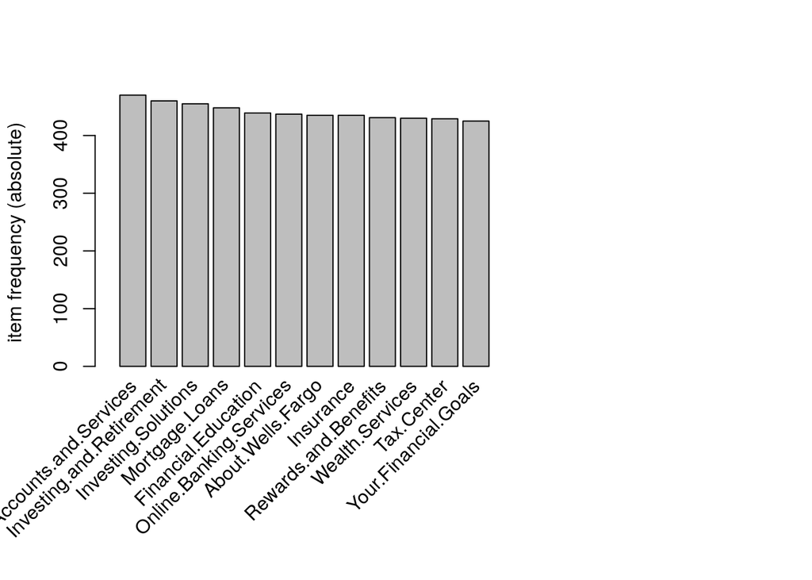

```r
itemFrequencyPlot(transactions,topN=20,type="absolute")
```

```r
rules <- apriori(transactions, parameter = list(supp = 0.001, conf = 0.3))
```

```
##
## Parameter specification:
##  confidence minval smax arem  aval originalSupport support minlen maxlen
##         0.3    0.1    1 none FALSE            TRUE   0.001      1     10
##  target   ext
##   rules FALSE
##
## Algorithmic control:
##  filter tree heap memopt load sort verbose
##     0.1 TRUE TRUE  FALSE TRUE    2    TRUE
##
## apriori - find association rules with the apriori algorithm
## version 4.21 (2004.05.09)        (c) 1996-2004   Christian Borgelt
## set item appearances ...[0 item(s)] done [0.00s].
## set transactions ...[12 item(s), 3498 transaction(s)] done [0.00s].
## sorting and recoding items ... [12 item(s)] done [0.00s].
## creating transaction tree ... done [0.00s].
## checking subsets of size 1 2 3 4 done [0.00s].
## writing ... [6 rule(s)] done [0.00s].
## creating S4 object  ... done [0.00s].
```

```r
# Show the top 5 rules, but only 2 digits
options(digits=2)
inspect(rules)
```

```
##   lhs                       rhs                       support confidence lift
## 1 {About.Wells.Fargo,
##    Tax.Center}           => {Insurance}                0.0026       0.31  2.5
## 2 {Rewards.and.Benefits,
##    Tax.Center}           => {Online.Banking.Services}  0.0023       0.31  2.5
## 3 {Insurance,
##    Investing.Solutions,
##    Your.Financial.Goals} => {Mortgage.Loans}           0.0011       0.67  5.2
## 4 {Insurance,
##    Mortgage.Loans,
##    Your.Financial.Goals} => {Investing.Solutions}      0.0011       0.44  3.4
## 5 {Insurance,
##    Investing.Solutions,
##    Mortgage.Loans}       => {Your.Financial.Goals}     0.0011       0.44  3.7
## 6 {Investing.Solutions,
##    Mortgage.Loans,
##    Your.Financial.Goals} => {Insurance}                0.0011       0.50  4.0
```